# 5. ggplot2 (Scatter plot)

Masahiko Asano

2026-11-10

- `R Packages` we use in this section

```r
library(DT)
library(gapminder)
library(gghighlight)
library(ggrepel)
library(stargazer)
library(tidyverse)
```

# 1. What is a Scatter plot?

- `A scatter plot` is a common method of visualizing the relationship between two continuous variables (variables measured on an interval or ratio scale).
- A scatter plot visualizes multiple points on a two-dimensional plane.
- The geometric objects used here are ggplot() and geom_point().

| **Geometric Object** | **Meaning** |
| --- | --- |
| **`ggplot()`** | Prepare the canvas for drawing the figure |
| **`geom_point()`** | Draw the scatter plot |

Download hr96-26.csv

```r
df <- read_csv("data/hr96-26.csv",
               na = ".")
```

- Extract the data from 2009 and name it `df09`.

```r
df09 <- df %>%
  filter(year == 2009)
```

## 1.1 The Simplest Scatter Plot

- Map the horizontal axis position to x and the vertical axis position to y.
- When considering a cause-and-effect relationship (causal relationship) between two variables:
- Set the factor thought to be the cause on the x axis (here, Election Expenses: `exp`).
- Set the factor thought to be the result on the y axis (here, Vote Share: `voteshare`).

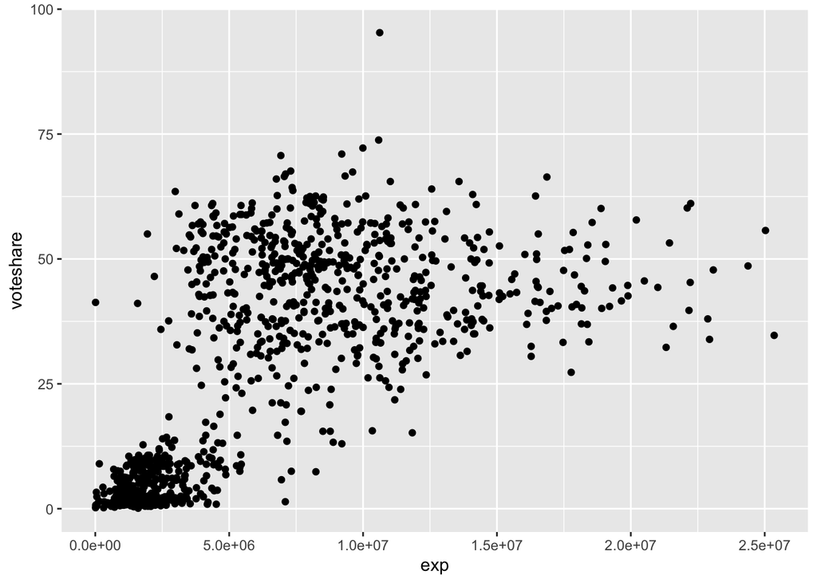

```r
df09 %>%
  ggplot() +
  geom_point(aes(x = exp,
                 y = voteshare))
```

- The horizontal and vertical axis titles are `exp` and `voteshare`.
- These titles may not be clear to the viewer in terms of what they represent.  
  => We need to specify what they mean.

### There are two ways of adding a regression line

- Move aes() inside ggplot()

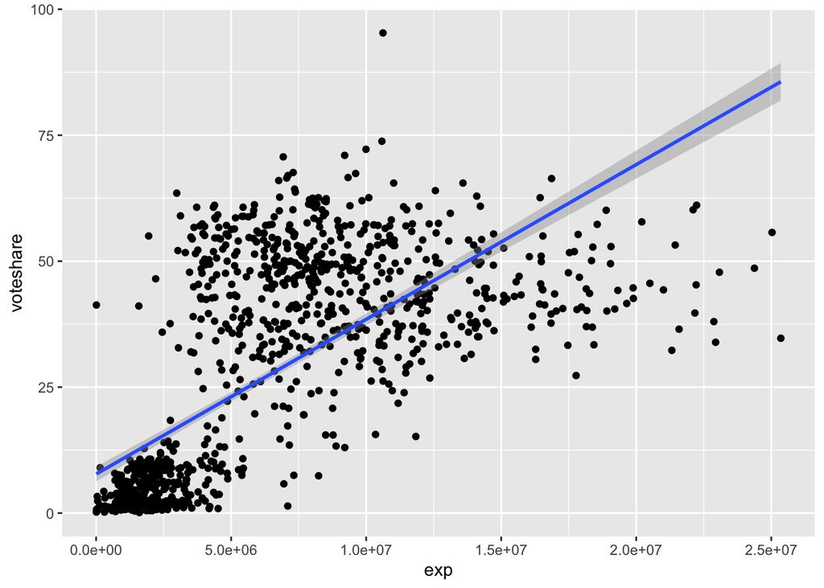

```r
df09 %>%
  ggplot(aes(x = exp,
                 y = voteshare)) +
  geom_point() +
  geom_smooth(method = "lm")
```

- Specify aes() in geom_smooth() as well

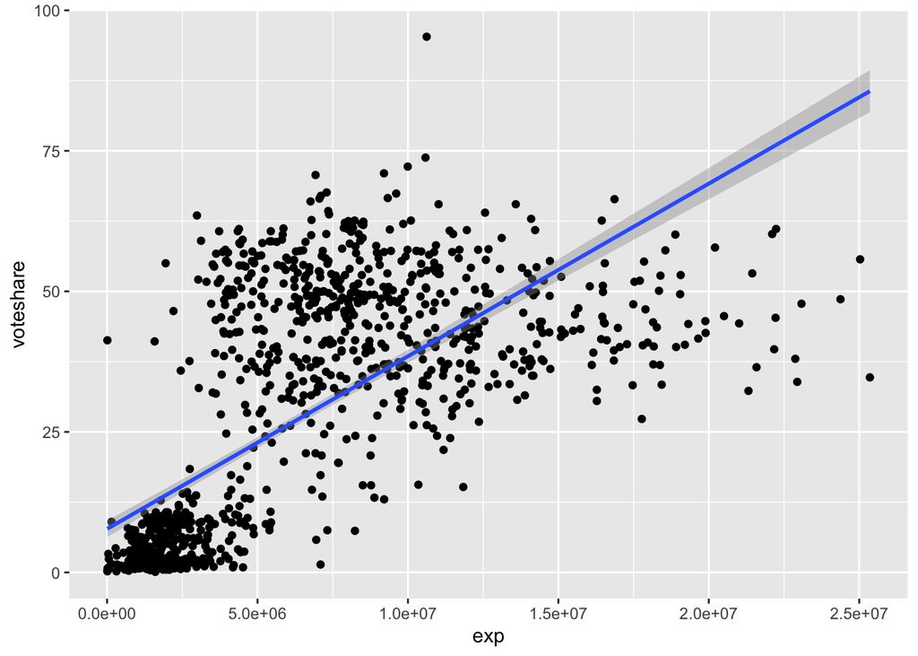

```r
df09 %>%
  ggplot() +
  geom_point(aes(x = exp, y = voteshare)) +
  geom_smooth(aes(x = exp, y = voteshare),
              method = "lm")
```

## 1.2 Customizing Labels and Dot Colors

- Add labels to the x and y axes.
- Use the `ggtitle()` function to add a main title.
- Specify the color of the dots.

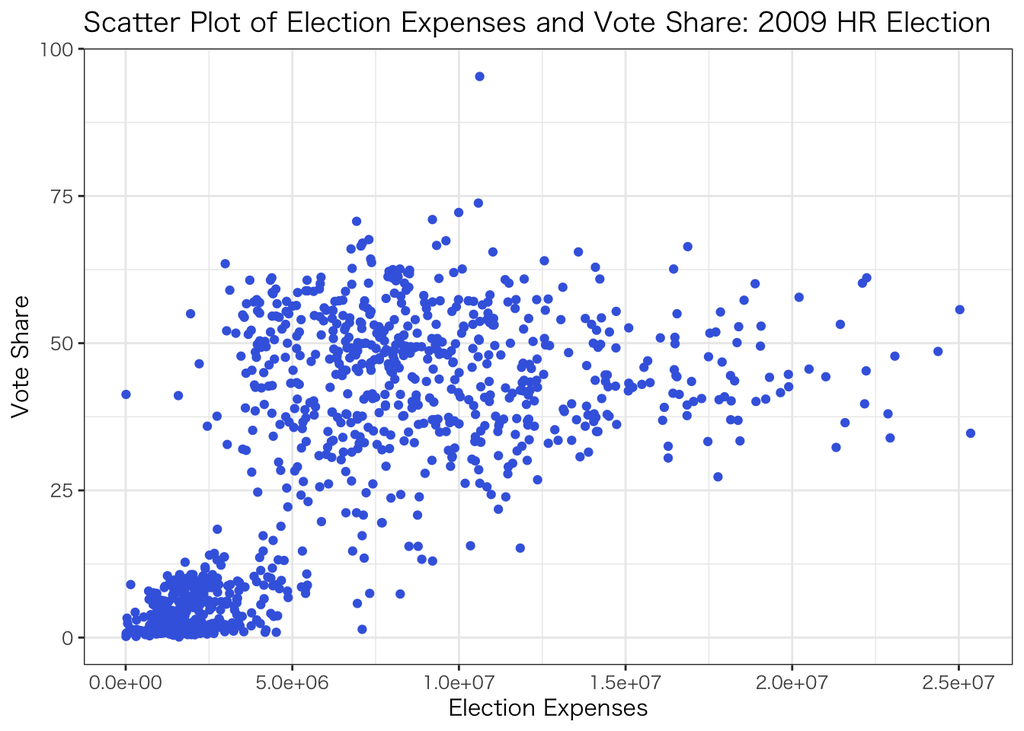

```r
df09 %>%
   ggplot() +
   geom_point(aes(x = exp,
                  y = voteshare),
              color = "royalblue") +
   labs(x = "Election Expenses",
        y = "Vote Share") +
  ggtitle("Scatter Plot of Election Expenses and Vote Share: 2009 HR Election") +
  theme_bw(base_family = "HiraKakuProN-W3")
```

## 1.3 Customizing the Shape of Dots

- You can specify the shape of the dots using `shape = number`.
- Here, let’s try setting it to a triangle (`△`).

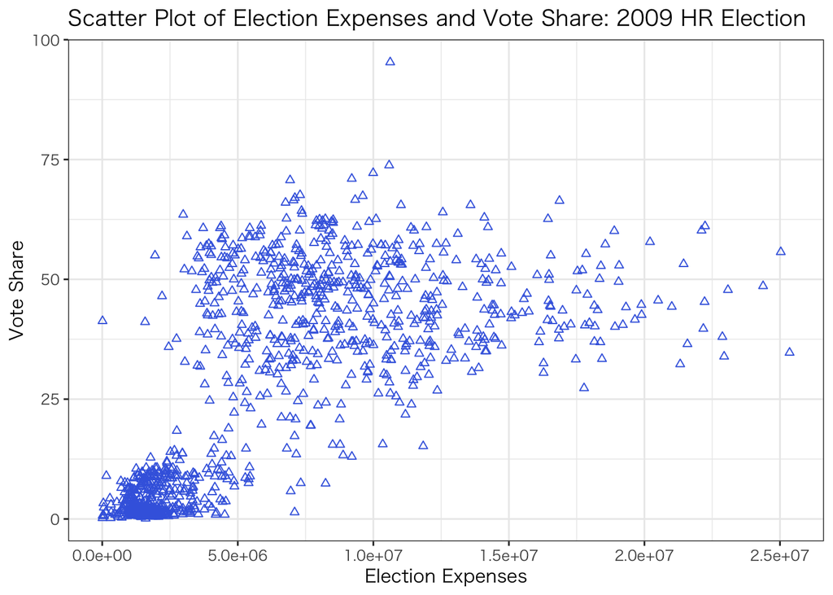

```r
df09 %>%
   ggplot() +
   geom_point(aes(x = exp,
                  y = voteshare),
              color = "royalblue",
              shape = 2) +
   labs(x = "Election Expenses",
        y = "Vote Share") +
  ggtitle("Scatter Plot of Election Expenses and Vote Share: 2009 HR Election") +
  theme_bw(base_family = "HiraKakuProN-W3")
```

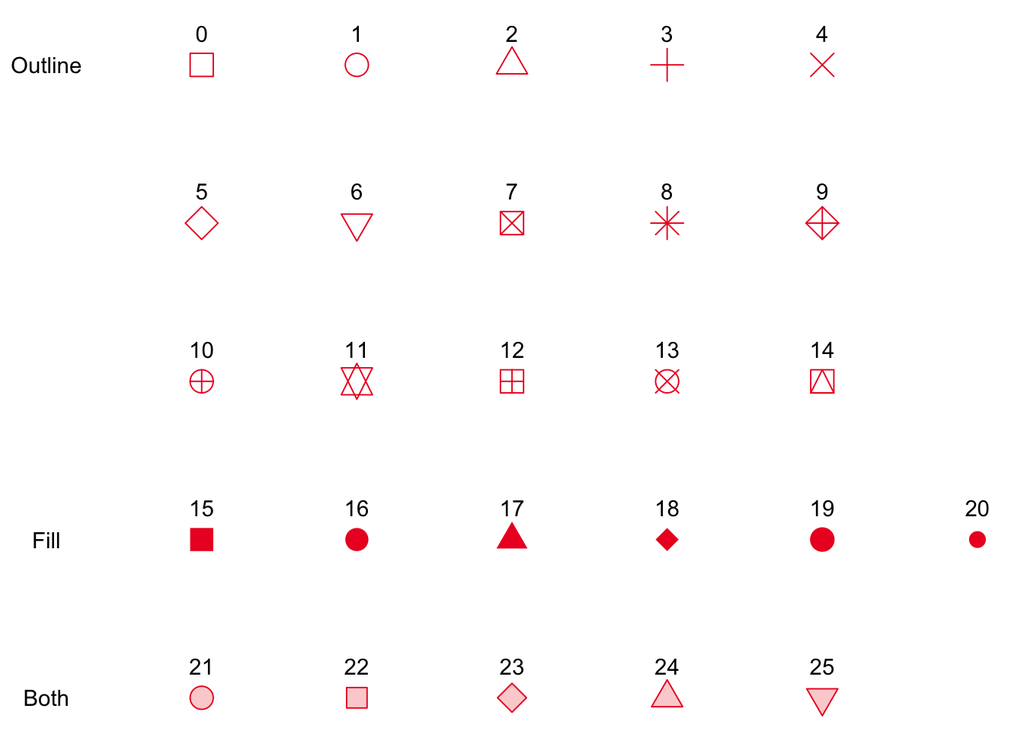

| **Shapes** | **Details** |
| --- | --- |
| 0〜14 | These are shapes with transparent insides and only outlines. |
| 15〜20 | These are solid shapes without outlines. |
| 21〜25 | The outline is adjusted with color, and the inside fill color is adjusted with fill. |

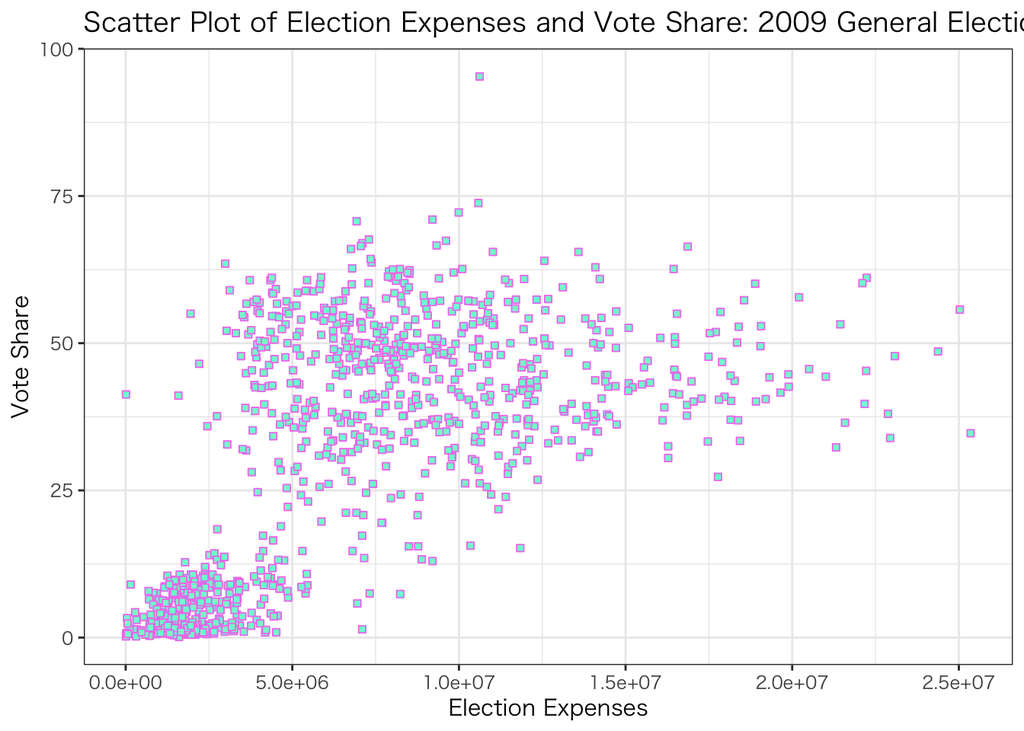

```r
df09 %>%
   ggplot() +
   geom_point(aes(x = exp,
                  y = voteshare),
              color = "violet",    # Specify the color of the outline
              fill = "aquamarine",  # Specify the color for the inside fill
              shape = 22) +        # Specify the shape of the dot
   labs(x = "Election Expenses",
        y = "Vote Share") +
  ggtitle("Scatter Plot of Election Expenses and Vote Share: 2009 General Election") +
  theme_bw(base_family = "HiraKakuProN-W3")
```

# 2. Adding Dimensions

- The scatter plot created in the previous section represents two pieces of information (= 2 dimensions): exp and voteshare. - Scatter plots can expand the number of pieces of information (= `dimensions`) they represent.
- Here, let’s use the `if_else()` function to create a Democratic Party dummy variable `dpj` and add a dimension to the scatter plot.
- Inside the `aes()` function, specify `shape = dpj`.

## 2.1 Adding Dimension by Changing the Shape of Dots

- Specify `shape = dpj` inside `aes()`.  
  → This allows changing the shape of the dot depending on whether it’s a Democratic Party candidate or not.
- `seito` contains party name each candidate is affilated with.
- `民主` means the Democratic Party Japan in Japanese.

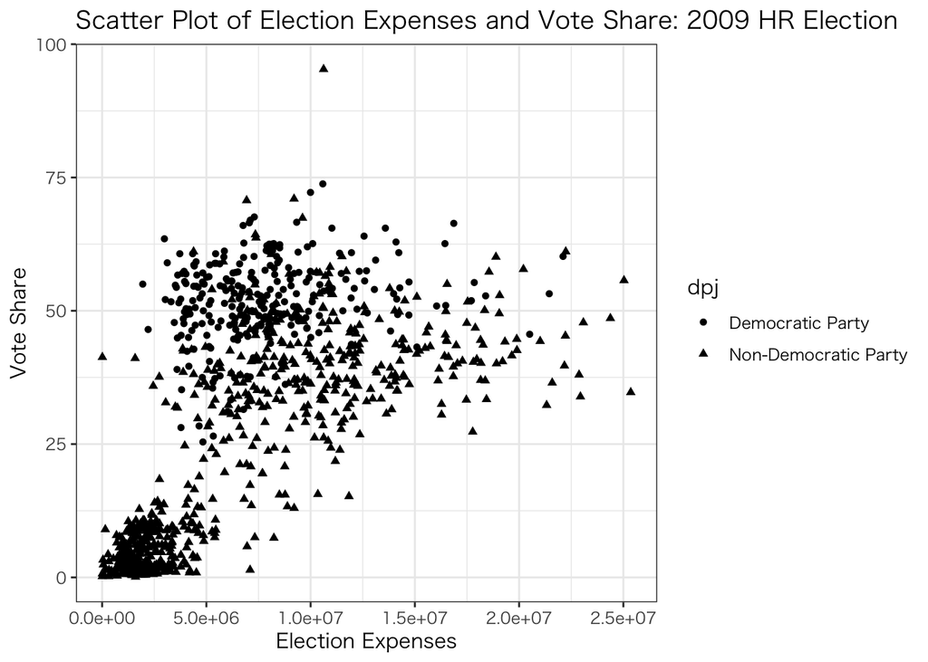

```r
df09 %>%
  mutate(dpj = if_else(seito == "民主", "Democratic Party", "Non-Democratic Party")) %>%
   ggplot() +
   geom_point(aes(x = exp,
                  y = voteshare,
                  shape = dpj)) +  # Differentiate dpj by the shape of the dot
   labs(x = "Election Expenses",
        y = "Vote Share") +
  ggtitle("Scatter Plot of Election Expenses and Vote Share: 2009 HR Election") +
  theme_bw(base_family = "HiraKakuProN-W3")
```

- When specifying `shape = dpj`, R automatically assigns shapes like ‘solid circle’ (●) and ‘triangle’ (▲).
- Although it’s possible to distinguish between Democratic Party candidates and others upon closer inspection, it’s hard to see the overall trend of Democratic Party candidates.  
  → Try specifying the shapes of the dots:  
  ・Democratic Party: ‘empty circle’ (○)  
  ・Non-Democratic Party: ‘cross’ (×)
- Use `scale_shape_manual()`.

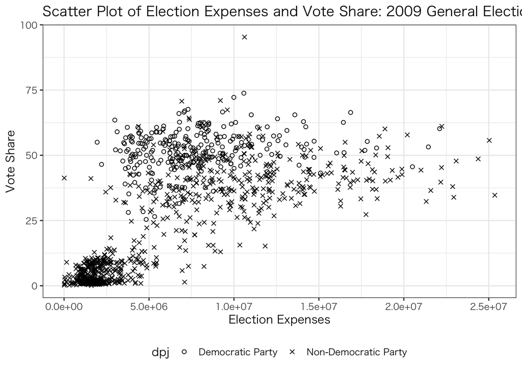

```r
df09 %>%
  mutate(dpj = if_else(seito == "民主", "Democratic Party", "Non-Democratic Party")) %>%
   ggplot() +
   geom_point(aes(x = exp,
                  y = voteshare,
                  shape = dpj)) +  # Differentiate dpj by the shape of the dot
   labs(x = "Election Expenses",
        y = "Vote Share") +
  ggtitle("Scatter Plot of Election Expenses and Vote Share: 2009 General Election") +
  theme_bw(base_family = "HiraKakuProN-W3")  +
  theme(legend.position = "bottom") + # Position the legend at the bottom
  scale_shape_manual(values = c("Democratic Party" = 1,    # 'empty circle' is 1
                                "Non-Democratic Party" = 4))  # 'cross' is 4
```

- It has become much easier to read than ‘solid circle’ (●) and ‘triangle’ (▲).

## 2.2 Adding Dimension by Changing the Dot Colors

- To make the trend of Democratic Party candidates more visible among all candidates:  
  → Try displaying with different colors.
- Inside the `aes()` function, specify `color = dpj`.

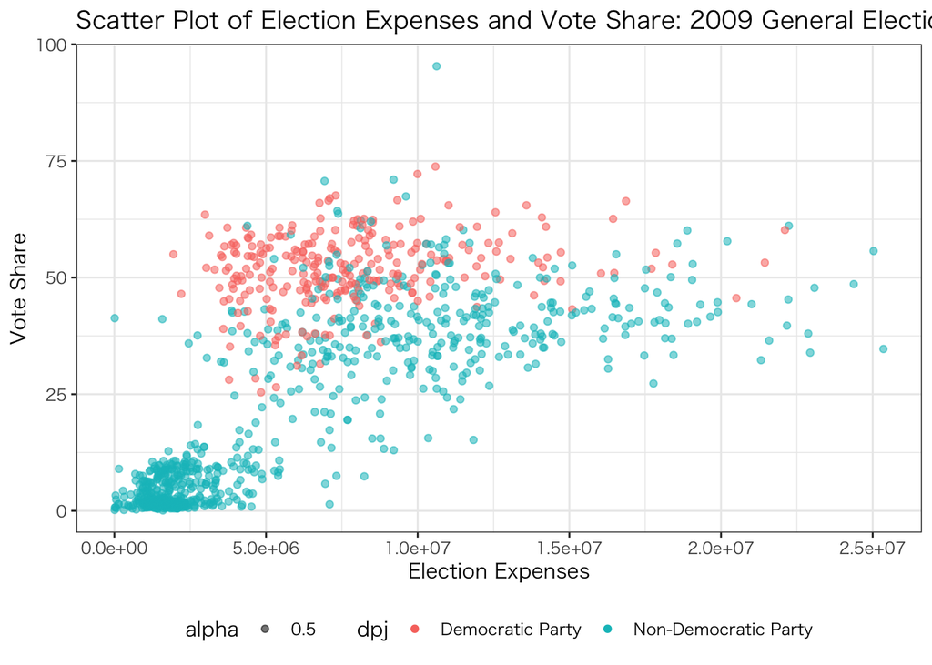

```r
df09 %>%
  mutate(dpj = if_else(seito == "民主", "Democratic Party", "Non-Democratic Party")) %>%
   ggplot() +
   geom_point(aes(x = exp,
                  y = voteshare,
                  color = dpj,    # Differentiate dpj by color
                  alpha = 0.5)) + # Add transparency
   labs(x = "Election Expenses",
        y = "Vote Share") +
  ggtitle("Scatter Plot of Election Expenses and Vote Share: 2009 General Election") +
  theme_bw(base_family = "HiraKakuProN-W3") +
  theme(legend.position = "bottom") # Position the legend at the bottom
```

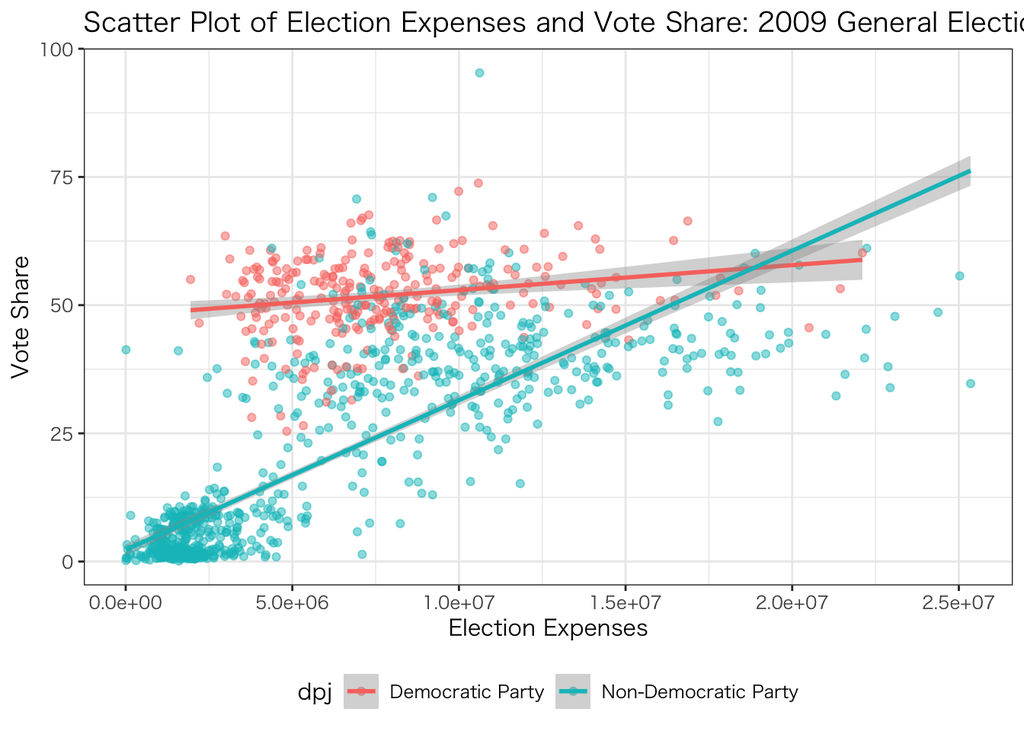

```r
df09 %>%
  mutate(dpj = if_else(seito == "民主",
                       "Democratic Party",
                       "Non-Democratic Party")) %>%
  ggplot(aes(x = exp, y = voteshare, color = dpj)) +
  geom_point(alpha = 0.5) +
  geom_smooth(method = "lm") +
  labs(x = "Election Expenses",
       y = "Vote Share",
       title = "Scatter Plot of Election Expenses and Vote Share: 2009 General Election") +
  theme_bw(base_family = "HiraKakuProN-W3") +
  theme(legend.position = "bottom")
```

- In the 2009 general election, where there was a power shift from the Liberal Democratic Party to the Democratic Party, it is clear that Democratic Party candidates tended to receive more votes.

## 2.3 Specifying Dot Colors

- If you want to specify the dots in your preferred colors:
- Add a `scale_color_manual()` layer.
- The argument is values.
- Specify as c(“value1” = “color1”, “value2” = “color2”, …):  
  → Specify a character type vector.

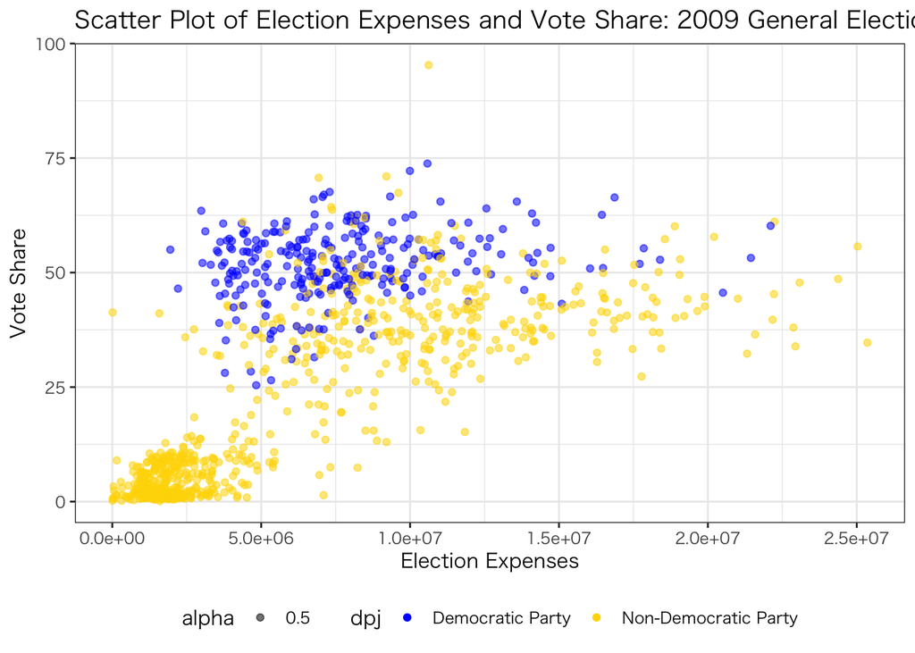

```r
df09 %>%
  mutate(dpj = if_else(seito == "民主", "Democratic Party", "Non-Democratic Party")) %>%
   ggplot() +
   geom_point(aes(x = exp,
                  y = voteshare,
                  color = dpj,    # Differentiate dpj by color
                  alpha = 0.5)) + # Add transparency
   labs(x = "Election Expenses",
        y = "Vote Share") +
  ggtitle("Scatter Plot of Election Expenses and Vote Share: 2009 General Election") +
  theme_bw(base_family = "HiraKakuProN-W3") +
  theme(legend.position = "bottom") + # Position the legend at the bottom
  scale_color_manual(values = c("Democratic Party" = "blue",
                                "Non-Democratic Party" = "gold"))
```

- In the 2009 general election, where there was a power shift from the Liberal Democratic Party to the Democratic Party, it is clear that Democratic Party candidates tended to receive more votes.
- There are 657 colors available for use in ggplot2!
- Colors can be specified by name, like “red”, “skyblue”, or “royalblue”.
- A list of colors available in R can be viewed by typing `colors()` in the console.
- Here, let’s show the first 6 colors.

```r
head(colors())
```

```
[1] "white"         "aliceblue"     "antiquewhite"  "antiquewhite1"
[5] "antiquewhite2" "antiquewhite3"
```

- In addition to named colors, you can also specify colors using RGB values (HEX codes; hexadecimal notation).
- For example, red can be specified as `#FF0000`, and royal blue as `#4169E1`.
- When using HEX codes, you can specify colors very precisely.  
  → This allows for 16,777,216 different colors!!!
- The following examples show a subset of the colors that can be used in R.

[figure not shown]

Source:https://blog.albertkuo.me/post/point-shape-options-in-ggplot/

# 3. Scatter Plot with Regression Line (1)

- Let’s add a regression line to the scatter plot of ‘Election Expenses’ and ‘Vote Share’ from the 2009 general election.
- To add a regression line, include `geom_smooth(method = lm)`.
- Specify the `aes()` function inside `ggplot()`, and set the x axis, y axis, and color.

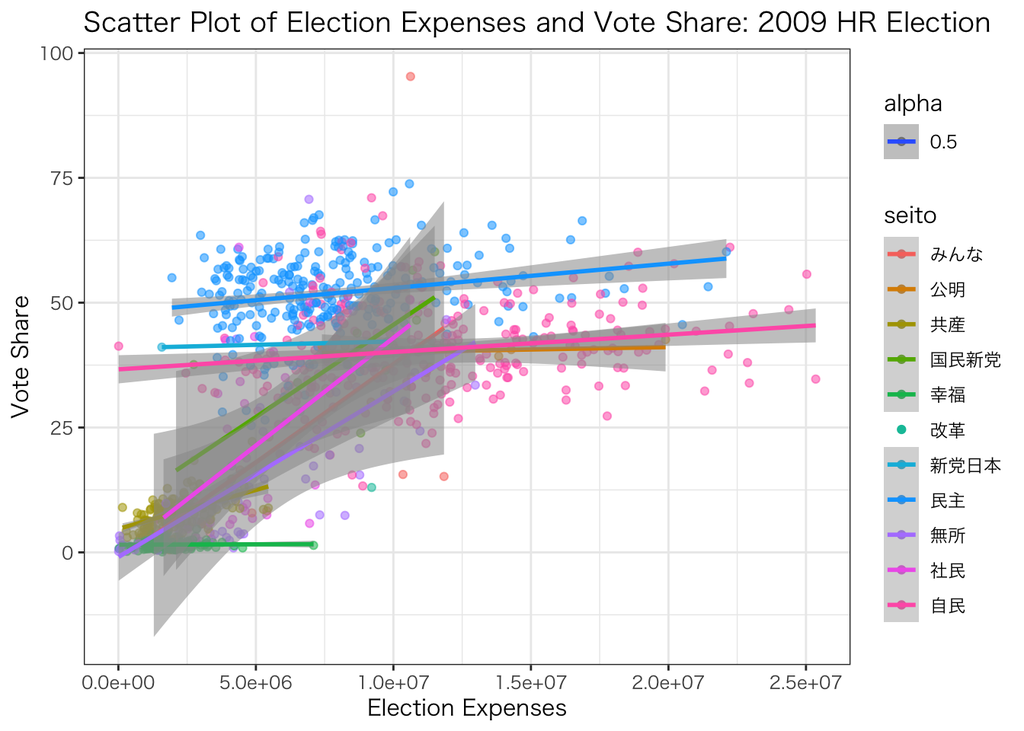

```r
plot_vs_09 <- df09 %>%
   ggplot(aes(x = exp,
              y = voteshare,
              color = seito,
              alpha = 0.5)) + # Specify the transparency of the dots
   geom_point() +
  geom_smooth(method = lm) +  # Draw the regression line
   labs(x = "Election Expenses",
        y = "Vote Share") +
  ggtitle("Scatter Plot of Election Expenses and Vote Share: 2009 HR Election") +
  theme_bw(base_family = "HiraKakuProN-W3")

plot_vs_09
```

- Let’s make it more readable by party using the `facet_wrap()` function.

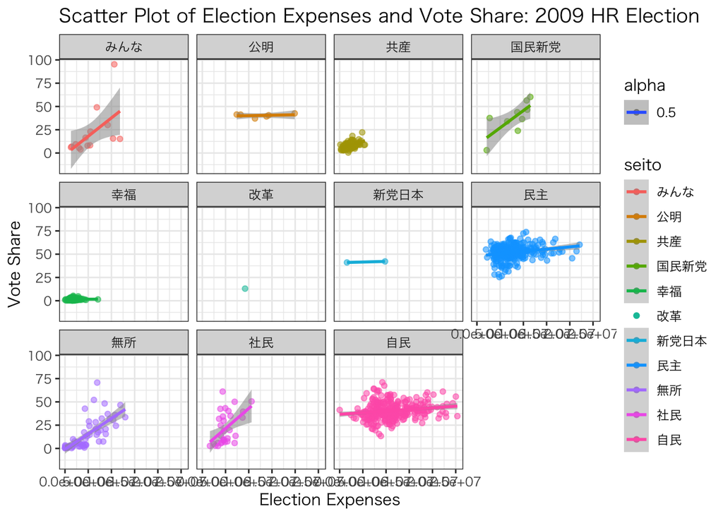

```r
plot_vs_09 +
  facet_wrap(~seito)    # Facet by each political party.
```

- The labels on the x axis are long and overlapping each other.  
  → Let’s try rotating the x axis labels by 40 degrees.
- Add a `theme()` layer and specify `axis.text.x.`

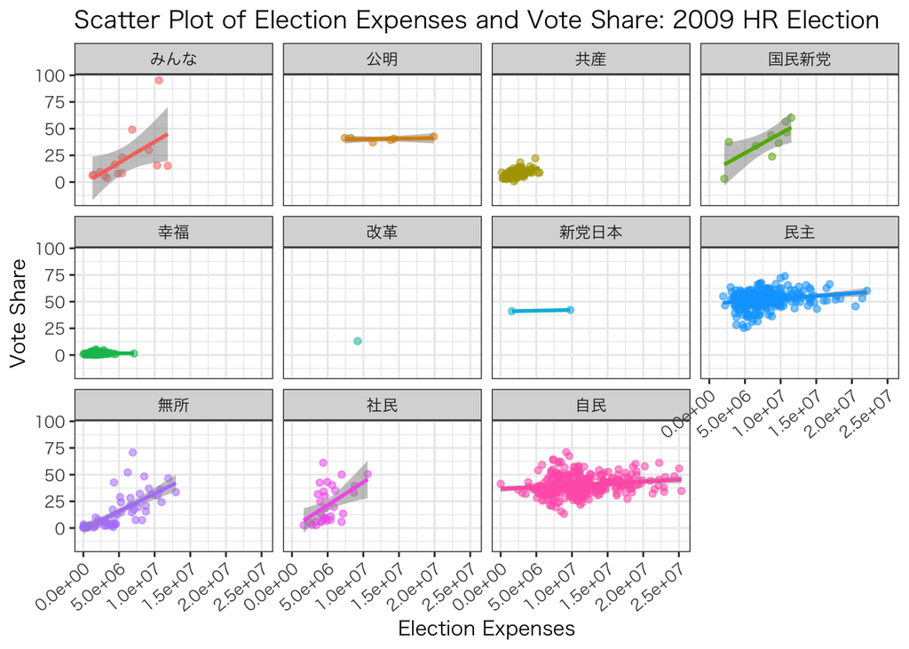

```r
plot_vs_09 +
  facet_wrap(~seito)  +  # Facet by political party
  theme(legend.position = "none") + # Hide the legend
  theme(axis.text.x  = element_text(angle = 40, vjust = 1, hjust = 1)) # Rotate by 35 degrees
```

- The 2009 general election was a power shift from the Liberal Democratic Party (LDP) to the Democratic Party.
- We want to compare the LDP and the Democratic Party.
- However, the plots for the LDP and the Democratic Party are not next to each other.
- Convert `seito` to a `factor` before passing it to `ggplot()` to change the order.

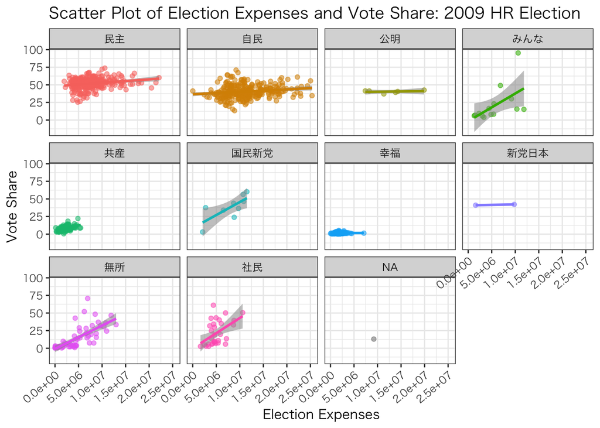

```r
df09 %>%
   mutate(seito = factor(seito,
                         levels = c("民主", "自民", "公明", "みんな",
                                    "共産", "国民新党", "幸福", "新党日本",
                                    "無所", "社民"))) %>%
   ggplot(aes(x = exp,
              y = voteshare,
              color = seito,
              alpha = 0.5)) + # Specify the transparency of the dots
   geom_point() +
  geom_smooth(method = lm) +  # Draw the regression line
   labs(x = "Election Expenses",
        y = "Vote Share") +
  ggtitle("Scatter Plot of Election Expenses and Vote Share: 2009 HR Election") +
  theme_bw(base_family = "HiraKakuProN-W3") +
  facet_wrap(~seito, ncol = 4) + # Display in 4 columns
  theme(legend.position = "none") + # Hide the legend
  theme(axis.text.x  = element_text(angle = 40, vjust = 1, hjust = 1)) # Rotate by 35 degrees
```

##### Visually Observable Insights

- The Democratic Party has received more votes than the Liberal Democratic Party.  
  The Democratic Party has spent less on election expenses than the Liberal Democratic Party.

#### Calculating Vote Share by Party

- Use the `group_by()` function to calculate the vote share for each party.

```r
df09_ave <- df09 %>%
  group_by(seito) %>%
  summarise(ave_vs = mean(voteshare,
                          na.rm = TRUE))
```

```r
DT::datatable(df09_ave)
```

|  | seito | ave_vs |
| --- | --- | --- |
| 1 | みんな | 20.93571428571429 |
| 2 | 公明 | 40.38333333333333 |
| 3 | 共産 | 7.930263157894736 |
| 4 | 国民新党 | 38.02222222222223 |
| 5 | 幸福 | 1.556506849315068 |
| 6 | 改革 | 13 |
| 7 | 新党日本 | 41.65000000000001 |
| 8 | 民主 | 51.77638376383764 |
| 9 | 無所 | 12.30285714285714 |
| 10 | 社民 | 21.6258064516129 |

[output cut: 1 more lines]

# 4. Scatter Plot with Regression Line (2)

- Scatter plot of ‘GDP’ and ‘Life Expectancy’.
- Here, we will use the `{gapminder}` data available in R to introduce a method for visualizing information in more than three dimensions on a two-dimensional plane.
- Download the {gapminder} package.

```r
library(gapminder)
```

- The [`{gapminder}`](https://cran.r-project.org/web/packages/gapminder/README.html) package includes the following variables:

| 変数名 | 詳細 |
| --- | --- |
| country | Country Name |
| continent | Continent Name |
| year | Year |
| lifeExp | Life Expectancy |
| pop | Population |
| gdpPercap | GDP per Capita, in US dollars as of 2005 |

- Show descriptive statistics.

```r
library(stargazer)
```

- Remeber to specify `{r, results = "asis"}` in the chunk options.

```r
stargazer(as.data.frame(gapminder),
          type ="html",
          digits = 2)
```

| Statistic | N | Mean | St. Dev. | Min | Max |
| --- | --- | --- | --- | --- | --- |
| year | 1,704 | 1,979.50 | 17.27 | 1,952 | 2,007 |
| lifeExp | 1,704 | 59.47 | 12.92 | 23.60 | 82.60 |
| pop | 1,704 | 29,601,212.00 | 106,157,897.00 | 60,011 | 1,318,683,096 |
| gdpPercap | 1,704 | 7,215.33 | 9,857.45 | 241.17 | 113,523.10 |

```r
DT::datatable(gapminder)
```

|  | country | continent | year | lifeExp | pop | gdpPercap |
| --- | --- | --- | --- | --- | --- | --- |
| 1 | Afghanistan | Asia | 1952 | 28.801 | 8425333 | 779.4453145 |
| 2 | Afghanistan | Asia | 1957 | 30.332 | 9240934 | 820.8530296 |
| 3 | Afghanistan | Asia | 1962 | 31.997 | 10267083 | 853.10071 |
| 4 | Afghanistan | Asia | 1967 | 34.02 | 11537966 | 836.1971382 |
| 5 | Afghanistan | Asia | 1972 | 36.088 | 13079460 | 739.9811058 |
| 6 | Afghanistan | Asia | 1977 | 38.438 | 14880372 | 786.11336 |
| 7 | Afghanistan | Asia | 1982 | 39.854 | 12881816 | 978.0114388 |
| 8 | Afghanistan | Asia | 1987 | 40.822 | 13867957 | 852.3959448 |
| 9 | Afghanistan | Asia | 1992 | 41.674 | 16317921 | 649.3413952 |
| 10 | Afghanistan | Asia | 1997 | 41.763 | 22227415 | 635.341351 |

[output cut: 1694 more lines]

## 4.1 Simple Scatter Plot {`gapminder`}

- First, let’s draw a scatter plot by specifying ‘GDP per Capita (`gdpPercap`)’ for the x axis and ‘Average Life Expectancy (`lifeExp`)’ for the y axis.
- Before passing to `ggplot()`, create a variable `pop_m` that converts the population into ‘millions of people’.

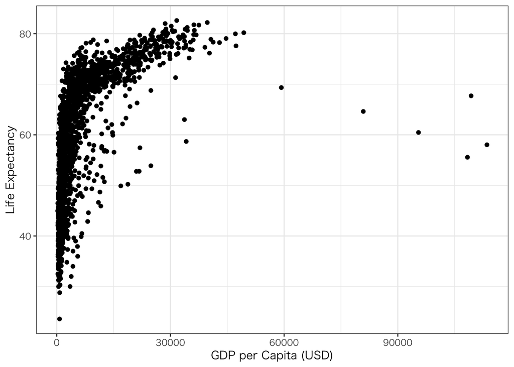

```r
gapminder %>%
  mutate(pop_m = pop / 1000000) %>%  # Create variable pop_m, converting population to millions
  ggplot() +
  geom_point(aes(x = gdpPercap,
                 y = lifeExp)) +
  labs(x = "GDP per Capita (USD)",
       y = "Life Expectancy") +
  theme_bw(base_family = "HiraKakuProN-W3")
```

- When looking at the descriptive statistics for ‘GDP per Capita’, the data range is very wide, extending from $241 (lowest) to $113,523 (highest).
- The relationship between ‘GDP per Capita’ and ‘Average Life Expectancy’ appears more logarithmic than linear.  
  → For better visibility, transform the x axis to log scale. Specify as `x = log(gdpPercap)`.

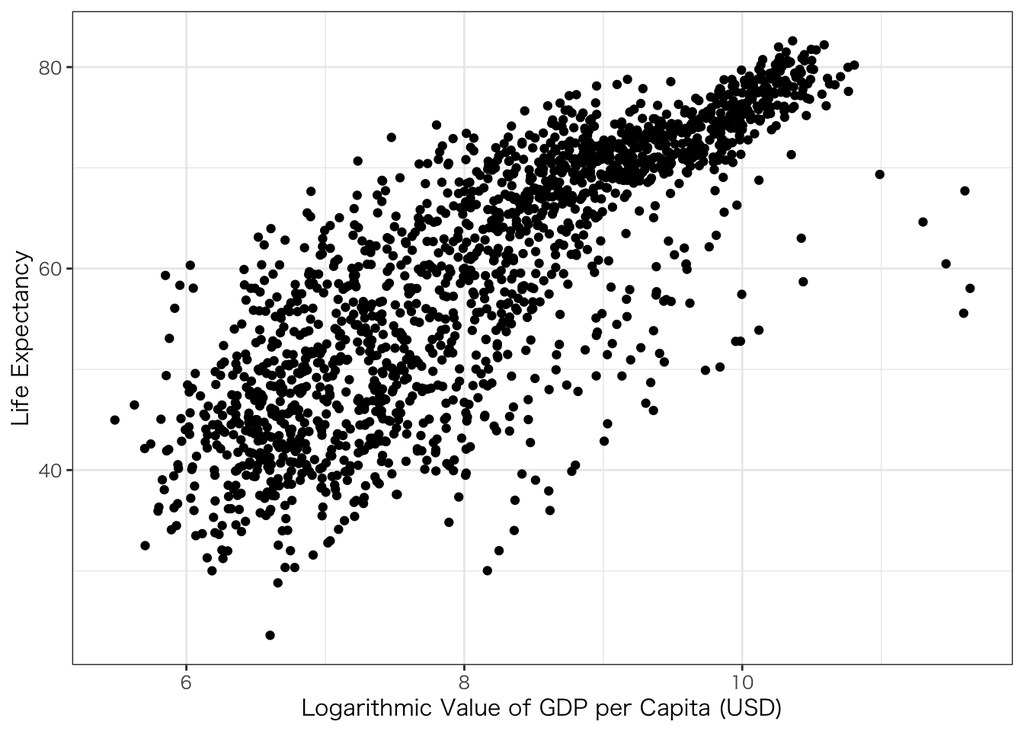

```r
gapminder %>%
  mutate(pop_m = pop / 1000000) %>%
  ggplot() +
  geom_point(aes(x = log(gdpPercap), # Log transform gdpPercap
                 y = lifeExp)) +
  labs(x = "Logarithmic Value of GDP per Capita (USD)",
       y = "Life Expectancy") +
  theme_bw(base_family = "HiraKakuProN-W3")
```

- After log-transforming `gdpPercap`, a quite clear linear relationship became apparent.
- Let’s check out the super-rich countries with exceptionally high ‘GDP per Capita’ located at the right end of the screen.

```r
gapminder %>%
  dplyr::filter(gdpPercap > 60000) %>%
  dplyr::select(year, country, gdpPercap)
```

```
# A tibble: 5 × 3
   year country gdpPercap
  <int> <fct>       <dbl>
1  1952 Kuwait    108382.
2  1957 Kuwait    113523.
3  1962 Kuwait     95458.
4  1967 Kuwait     80895.
5  1972 Kuwait    109348.
```

## 4.2 Add continents and population to the scatter plot.

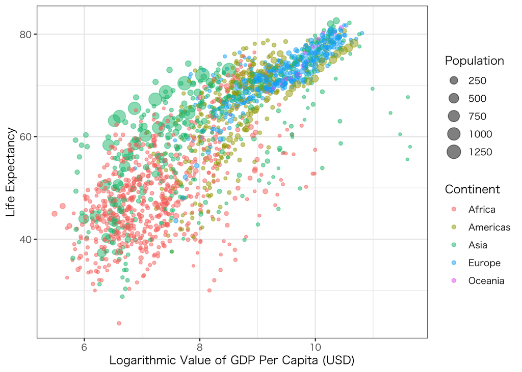

```r
gapminder %>%
  mutate(pop_m = pop / 1000000) %>%
  ggplot() +
  geom_point(aes(x = log(gdpPercap),
                 y = lifeExp,
                 color = continent,
                 size = pop_m),
             alpha = 0.5) +
  labs(x = "Logarithmic Value of GDP Per Capita (USD)",
       y = "Life Expectancy",
       size = "Population",
       color = "Continent") +
  theme_bw(base_family = "HiraKakuProN-W3")
```

## 4.3 Drawing a linear line

- Specify geom_smooth(method = lm) to draw a linear line.

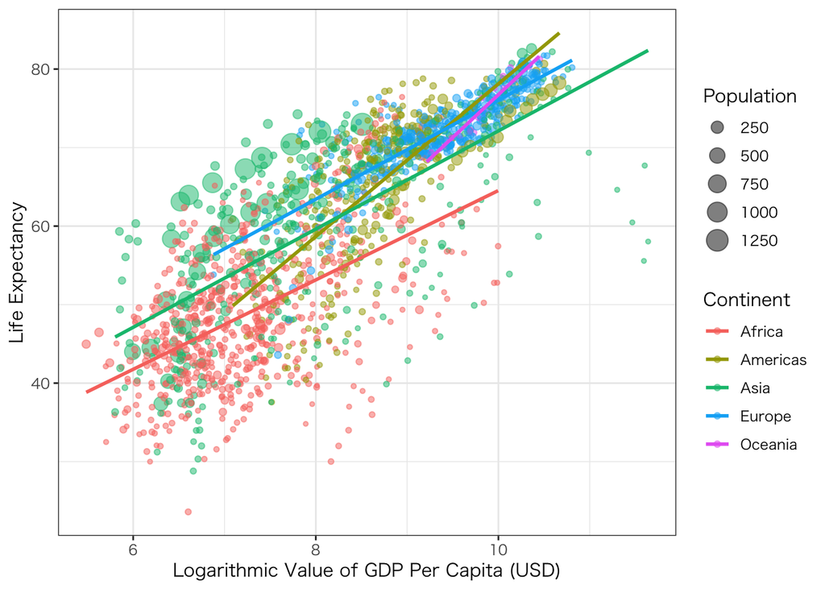

```r
gapminder %>%
  mutate(pop_m = pop / 1000000) %>%
  ggplot() +
  geom_point(aes(x = log(gdpPercap),
                 y = lifeExp,
                 color = continent,
                 size = pop_m),
             alpha = 0.5) +

  geom_smooth(aes(
      x = log(gdpPercap),
      y = lifeExp,
      color = continent),
    method = "lm",
    se = FALSE) +

  labs(x = "Logarithmic Value of GDP Per Capita (USD)",
       y = "Life Expectancy",
       size = "Population",
       color = "Continent") +
  theme_bw(base_family = "HiraKakuProN-W3")
```

## 4.4 Display categorized by dimensions

- Use `facet_wrap(~continent)` to draw separate scatter plots for each continent.

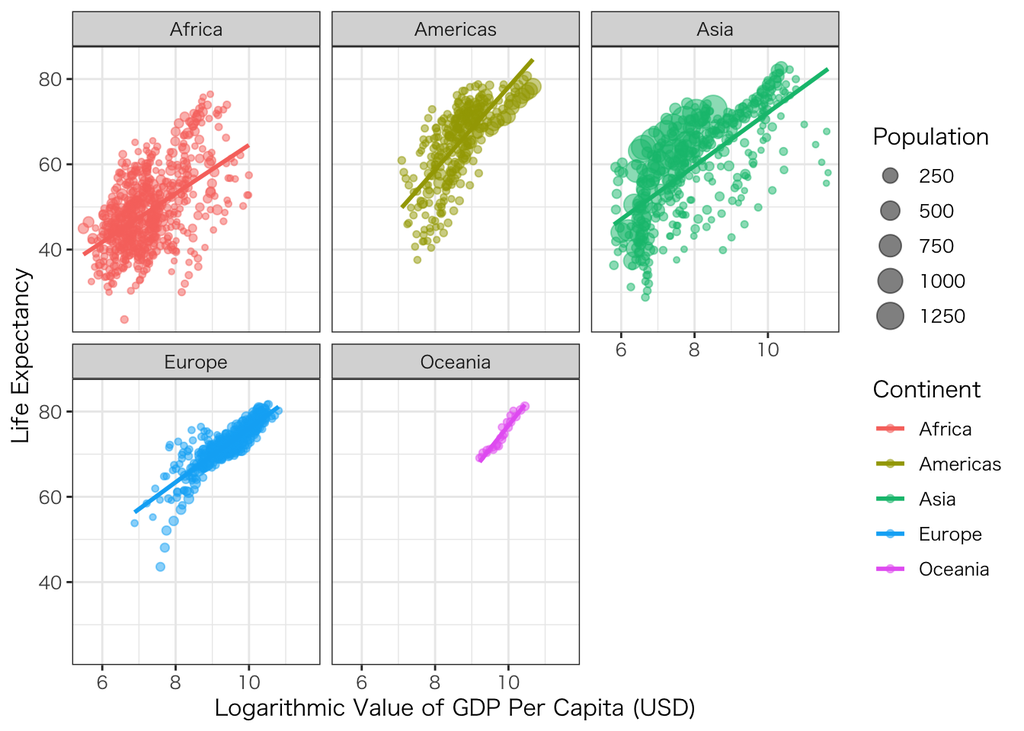

```r
gapminder %>%
  mutate(pop_m = pop / 1000000) %>%
  ggplot() +
  geom_point(aes(x = log(gdpPercap),
                 y = lifeExp,
                 color = continent,
                 size = pop_m),
             alpha = 0.5) +

  geom_smooth(aes(
      x = log(gdpPercap),
      y = lifeExp,
      color = continent),
    method = "lm",
    se = FALSE) +

  labs(x = "Logarithmic Value of GDP Per Capita (USD)",
       y = "Life Expectancy",
       size = "Population",
       color = "Continent") +
  theme_bw(base_family = "HiraKakuProN-W3") +
  facet_wrap(~continent)
```

## 4.5 Highlighting Specific Countries

- Try identifying data for Japan, the United States, and China. Use the `{gghighlight} package`.

```r
library(gghighlight)
```

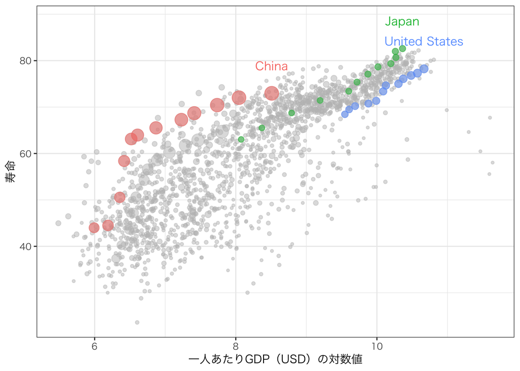

```r
gapminder %>%
  mutate(pop_m = pop / 1000000) %>%
  ggplot(aes(
      x = log(gdpPercap),
      y = lifeExp,
      color = country,
      size = pop_m)) +
  geom_point(alpha = 0.5) +
  gghighlight(
    country %in% c("Japan", "China", "United States")) +
  geom_text(data = gapminder %>%
      filter(year == 2007,
        country %in% c("Japan", "China", "United States")),
    aes(label = country),
    nudge_y = 6,
    size = 4,
    show.legend = FALSE) +
  labs(x = "一人あたりGDP（USD）の対数値",
    y = "寿命",
    size = "人口",
    color = "国") +
  guides(size = "none",color = "none") +
  theme_bw(base_family = "HiraKakuProN-W3")
```

# 5. Displaying Text in a Scatter Plot

##5.1 Data Preparation  
- In this section, we consider a scatter plot using data on eligible voters aged 18 and the voting rate.  
- Download the data from the 24th (2016) House of Councillors election `vote_18.csv` and save it in the RProject folder.  
- Load the data.

```r
hc2016 <- read_csv("data/vote_18.csv")
```

- 変数の詳細は次のとおり

| Variable Name | Details |
| --- | --- |
| pref | Prefecture |
| age18 | Voting rate of eligible voters aged 18 |
| age19 | Voting rate of eligible voters aged 19 |
| age1819 | Voting rate of eligible voters aged 18 and 19 |
| all | Voting rate of the prefecture |
| did | Population density of the prefecture |

- Displaying Descriptive Statistics of the Data.
- Note: Enter {r, results = “asis”} in the chunk options

```r
stargazer(data.frame(hc2016),
          type = "html")
```

| Statistic | N | Mean | St. Dev. | Min | Max |
| --- | --- | --- | --- | --- | --- |
| serial | 47 | 24.000 | 13.711 | 1 | 47 |
| age18 | 47 | 48.389 | 5.307 | 35.290 | 62.230 |
| age19 | 47 | 38.419 | 6.033 | 26.580 | 53.800 |
| age1819 | 47 | 43.446 | 5.558 | 30.930 | 57.840 |
| all | 47 | 54.968 | 3.887 | 45.520 | 62.860 |
| did | 47 | 655.374 | 1,194.258 | 68.650 | 6,168.040 |

- Use the `{DT} package` to display interactive descriptive statistics of the data.

```r
DT::datatable(hc2016)
```

|  | serial | pref | age18 | age19 | age1819 | all | did |
| --- | --- | --- | --- | --- | --- | --- | --- |
| 1 | 3 | 愛知 | 58.2 | 49.4 | 53.77 | 55.41 | 1446.91 |
| 2 | 45 | 愛媛 | 41.43 | 29.9 | 35.78 | 56.36 | 244.15 |
| 3 | 23 | 茨城 | 47.73 | 37.93 | 42.85 | 50.77 | 478.57 |
| 4 | 35 | 岡山 | 45.34 | 33.74 | 39.53 | 50.86 | 270.18 |
| 5 | 25 | 沖縄 | 46.07 | 38.99 | 42.58 | 54.46 | 628.7 |
| 6 | 21 | 岩手 | 47.97 | 37.74 | 43.03 | 57.78 | 83.78 |
| 7 | 9 | 岐阜 | 52.9 | 45.05 | 49.01 | 57.74 | 191.36 |
| 8 | 46 | 宮崎 | 38.54 | 28.07 | 33.61 | 49.76 | 142.77 |
| 9 | 14 | 宮城 | 49.99 | 41.39 | 45.65 | 52.39 | 320.54 |
| 10 | 11 | 京都 | 51.12 | 42.78 | 46.86 | 51.16 | 565.92 |

[output cut: 37 more lines]

#### For reference:

- if you just want to display the entire dataframe on the screen at once, enter the command `knitr::kable(hr2005)`.
- Data sources: Data on the voting rate of 18 and 19-year-olds in the 24th House of Councillors ordinary election: Ministry of Internal Affairs and Communications, conducted on July 10, 2016 (Heisei 28).
- The population density data (`did`) is downloadabale here [Data as of April 1, 2016](https://uub.jp/rnk/rnk.cgi?T=p&S=j&B=20160401)

## 5.2 Adding dimensions to a scatter plot.

### 5.2.1 Making Scatter Plots More Readable

- “Urbanization index” and “Turnout”.
- Add dimensions (prefecture names) to the scatter plot of “Urbanization index” and “Turnout”.
- Specify “Urbanization index (did)” on the x-axis and “Turnout” on the y-axis to create the scatter plot.
- Use the `geom_text()` function to display prefecture names.

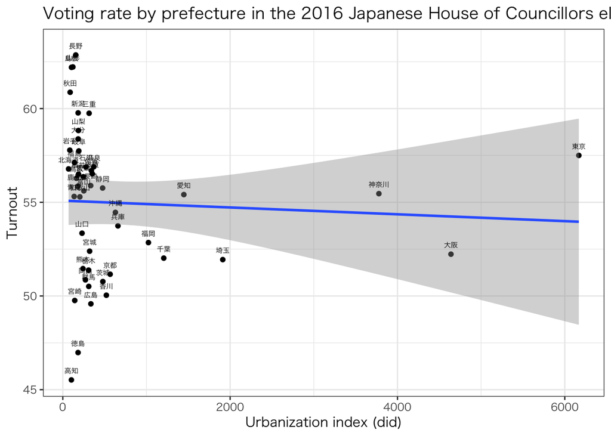

```r
hc2016 %>%
  ggplot(aes(did, all)) +
  geom_point() +
  stat_smooth(method = lm) +
  geom_text(aes(y = all + 0.5,
                label = pref),
            size = 2,
            family = "HiraKakuPro-W3") +
  labs(x = "Urbanization index (did)", y = "Turnout") +
  ggtitle("Voting rate by prefecture in the 2016 Japanese House of Councillors election") +
  theme_bw(base_family = "HiraKakuProN-W3")
```

- The text overlaid on the prefectures is difficult to distinguish in the graph:
- The three prefectures with the highest population density, Tokyo, Osaka, and Kanagawa, are isolated on the right as outliers.
- This makes the graph hard to read.

### Solutions:

1. Exclude outliers (in this case, Tokyo（東京）, Osaka（大阪）, and Kanagawa（神奈川）) from the data.
2. Apply a logarithmic transformation to variables with large value differences (in this case, the degree of urbanization did).

#### (1) Scatter Plot Excluding Specific ‘Outliers’.

- Draw a scatter plot excluding the top three prefectures with high population density: Tokyo, Osaka, and Kanagawa.
- The ‘degree of urbanization’ of these three prefectures is visually over 2000.  
  → Specify `dplyr::filter(did < 2000)`.

#### {ggrepel}:

- Use the {ggrepel} package to make the display of prefecture names more readable and spread out.”

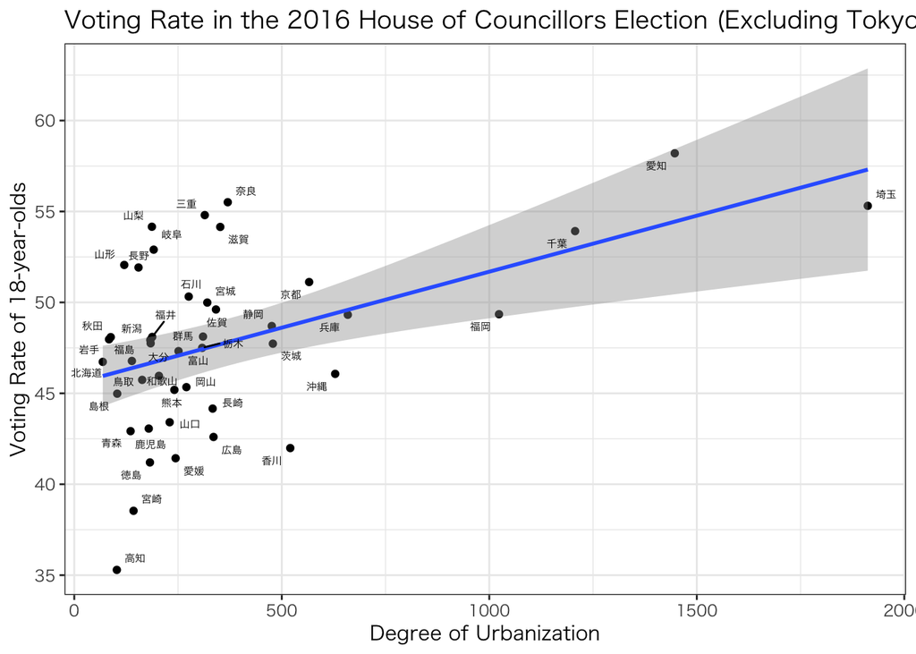

```r
hc2016 %>%
  filter(did < 2000) %>% # Exclude Tokyo, Osaka, Kanagawa
  ggplot(aes(did, age18)) +
  geom_point() +
  stat_smooth(method = lm) +
  ggrepel::geom_text_repel(aes(label = pref),
            size = 2,
            family = "HiraKakuPro-W3") +
  labs(x = "Degree of Urbanization", y = "Voting Rate of 18-year-olds") +
  ggtitle("Voting Rate in the 2016 House of Councillors Election (Excluding Tokyo, Osaka, Kanagawa)") +
  theme_bw(base_family = "HiraKakuProN-W3")
```

- This makes the graph much easier to read.  
- However, there is a downside of not including the three outliers.

#### (2) Scatter Plot with Logarithmic Transformation of ‘Degree of Urbanization (did)’.

→ To improve readability, transform the x-axis ‘Degree of Urbanization (did)’ to logarithmic scale.  
- Specify x = log(did).

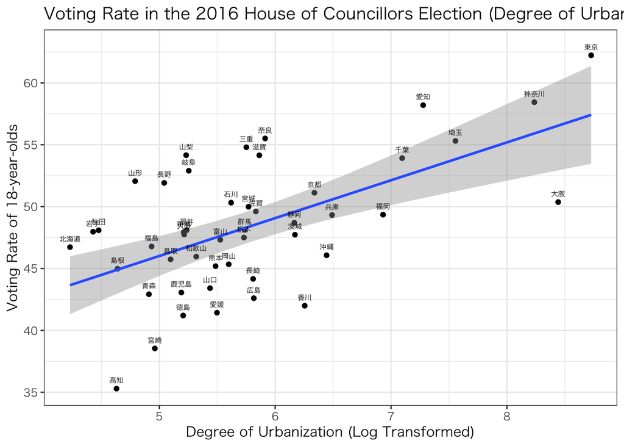

```r
hc2016 %>%
  ggplot(aes(log(did), age18)) +
  geom_point() +
  stat_smooth(method = lm) +
  geom_text(aes(y = age18 + 0.7,
                label = pref),
            size = 2,
            family = "HiraKakuPro-W3") +
  labs(x = "Degree of Urbanization (Log Transformed)", y = "Voting Rate of 18-year-olds") +
  ggtitle("Voting Rate in the 2016 House of Councillors Election (Degree of Urbanization Log Transformed)") +
  theme_bw(base_family = "HiraKakuProN-W3")
```

- This significantly improves the readability of the graph.
- It has the advantage of including all cases.
- However, there is a downside: if conducting regression analysis, the interpretation of coefficients is not straightforward.

#### Placing Prefecture Names in Boxes.

- There is also a method to place prefecture names in boxes using the `geom_text_repel()` function.

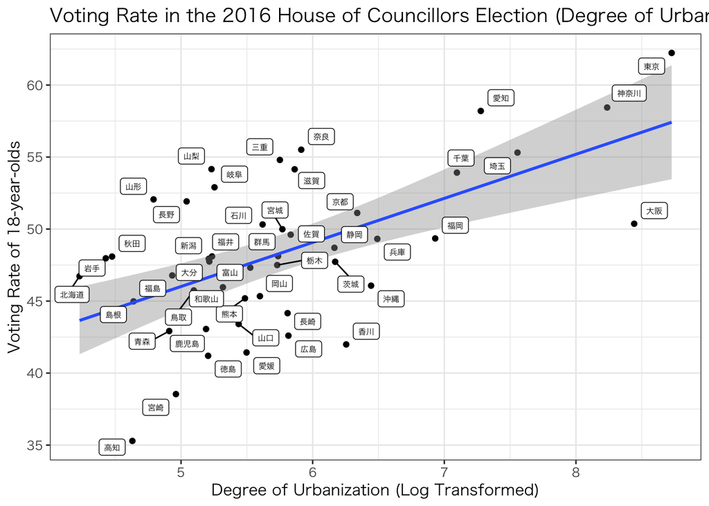

```r
hc2016 %>%
  ggplot(aes(log(did), age18)) +
  geom_point() +
  stat_smooth(method = lm) +
  ggrepel::geom_label_repel(aes(label = pref),
            size = 2,
            family = "HiraKakuPro-W3") +
  labs(x = "Degree of Urbanization (Log Transformed)", y = "Voting Rate of 18-year-olds") +
  ggtitle("Voting Rate in the 2016 House of Councillors Election (Degree of Urbanization Log Transformed)") +
  theme_bw(base_family = "HiraKakuProN-W3")
```

Summary of the 24th House of Councillors Election Data (2016) ・There is a very weak negative correlation between ‘voting rate by prefecture’ and ‘degree of urbanization’.  
→ Almost no correlation.  
・However, there is a positive correlation between ‘voting rate of 18-year-olds’ and ‘degree of urbanization’”

### 5.2.2 Highlighting Specific Points with Label Display

- It is possible to highlight only the data that meets certain conditions and also display the names of the prefectures.
- In this case, we will highlight and display only the six prefectures of the Tohoku region.

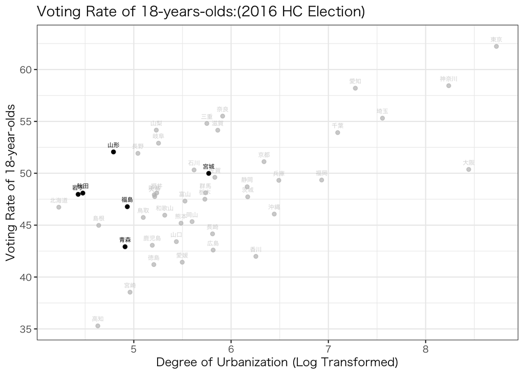

```r
hc2016 %>%
  ggplot(aes(log(did), age18)) +
  geom_point() +
  geom_text(aes(y = age18 + 0.7,
                label = pref),
                size = 2,
    family = "HiraKakuPro-W3") +
  labs(x = "Degree of Urbanization (Log Transformed)",
    y = "Voting Rate of 18-year-olds") +
  ggtitle("Voting Rate of 18-years-olds:(2016 HC Election)") +
  theme_bw(base_family = "HiraKakuProN-W3") +
  gghighlight::gghighlight(
    pref == "青森"|
      pref == "秋田"|
      pref == "岩手"|
      pref == "山形"|
      pref == "宮城"|
      pref == "福島")
```

- If `stat_smooth(method = lm)` is added, it’s possible to simultaneously display the regression line for all prefectures and a separate regression line just for the six Tohoku prefectures.

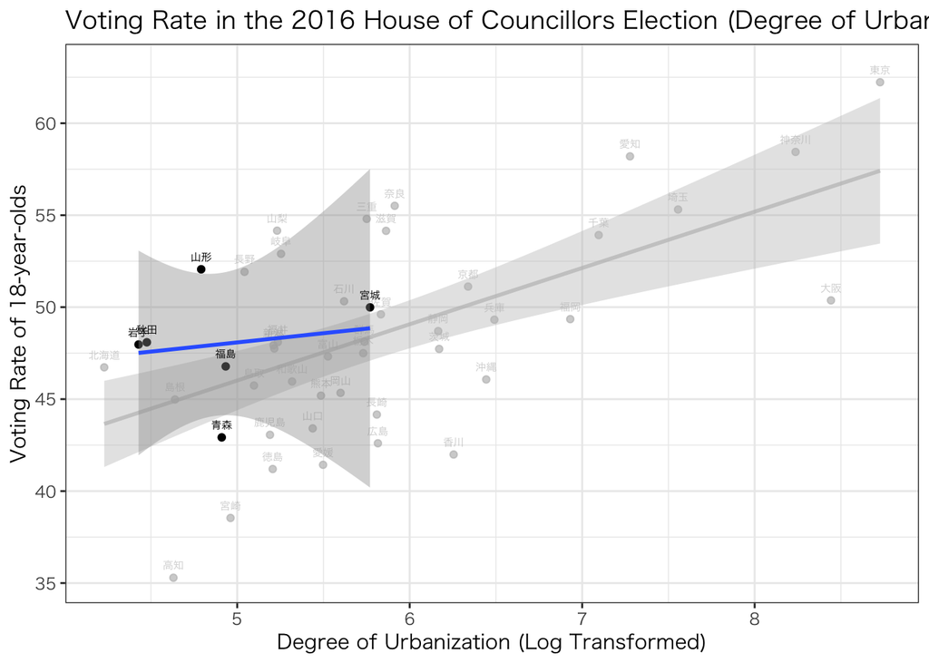

```r
hc2016 %>%
  ggplot(aes(log(did), age18)) +
  geom_point() +
  stat_smooth(method = lm) +
  geom_text(aes(y = age18 + 0.7,
                label = pref),
            size = 2,
            family = "HiraKakuPro-W3") +
  labs(x = "Degree of Urbanization (Log Transformed)", y = "Voting Rate of 18-year-olds") +
  ggtitle("Voting Rate in the 2016 House of Councillors Election (Degree of Urbanization Log Transformed)") +
  theme_bw(base_family = "HiraKakuProN-W3") +
  gghighlight::gghighlight(
    pref == "青森"|
      pref == "秋田"|
      pref == "岩手"|
      pref == "山形"|
      pref == "宮城"|
      pref == "福島")
```

# 6. Scatterplot of Political Polarization in the US House of Representatives

## 6.1 Data Preparation

- Use data on the ideological points of all members regarding bills in the US House of Representatives from the 80th Congress (1947-1948) to the 112th Congress (2011-2012).

#### DW-NOMINATE Score

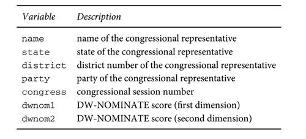

- Download the survey data targeting members of the US House of Representatives from (`congress.csv`).
- Load the data and name it `congress`

```r
congress <- read_csv("data/congress.csv")
```

- Check the variables in `congress`.

```r
names(congress)
```

```
[1] "congress" "district" "state"    "party"    "name"     "dwnom1"   "dwnom2"
```

- Display only the initial part of the variables

```r
head(congress)
```

```
# A tibble: 6 × 7
  congress district state   party    name          dwnom1 dwnom2
     <dbl>    <dbl> <chr>   <chr>    <chr>          <dbl>  <dbl>
1       80        0 USA     Democrat TRUMAN      -0.276   0.0160
2       80        1 ALABAMA Democrat BOYKIN  F.  -0.0260  0.796
3       80        2 ALABAMA Democrat GRANT  G.   -0.0420  0.999
4       80        3 ALABAMA Democrat ANDREWS  G. -0.00800 1.00
5       80        4 ALABAMA Democrat HOBBS  S.   -0.0820  1.07
6       80        5 ALABAMA Democrat RAINS  A.   -0.170   0.870
```

```r
tail(congress)
```

```
# A tibble: 6 × 7
  congress district state   party      name     dwnom1   dwnom2
     <dbl>    <dbl> <chr>   <chr>      <chr>     <dbl>    <dbl>
1      112        4 WISCONS Democrat   MOORE    -0.538 -0.458
2      112        5 WISCONS Republican SENSENBR  1.20  -0.438
3      112        6 WISCONS Republican PETRI     0.776 -0.00300
4      112        7 WISCONS Republican DUFFY     0.781 -0.270
5      112        8 WISCONS Republican RIBBLE    0.886 -0.193
6      112        1 WYOMING Republican LUMMIS    0.932 -0.211
```

- Use the `filter()` function to extract data for each Congress session.

```r
eighty <- congress %>%
  filter(congress == 80)  # 80th Congress

twelve <- congress %>%
  filter(congress == 112) # 112th Congress
```

- Display the beginning of the extracted data for the 80th Congress.

```r
head(eighty)
```

```
# A tibble: 6 × 7
  congress district state   party    name          dwnom1 dwnom2
     <dbl>    <dbl> <chr>   <chr>    <chr>          <dbl>  <dbl>
1       80        0 USA     Democrat TRUMAN      -0.276   0.0160
2       80        1 ALABAMA Democrat BOYKIN  F.  -0.0260  0.796
3       80        2 ALABAMA Democrat GRANT  G.   -0.0420  0.999
4       80        3 ALABAMA Democrat ANDREWS  G. -0.00800 1.00
5       80        4 ALABAMA Democrat HOBBS  S.   -0.0820  1.07
6       80        5 ALABAMA Democrat RAINS  A.   -0.170   0.870
```

## 6.2 Scatterplot of Data for the 80th Congress

- Let’s draw a scatter plot of data between economic issues (x-axis) and racial issues (y-axis) for the 80th Congress.

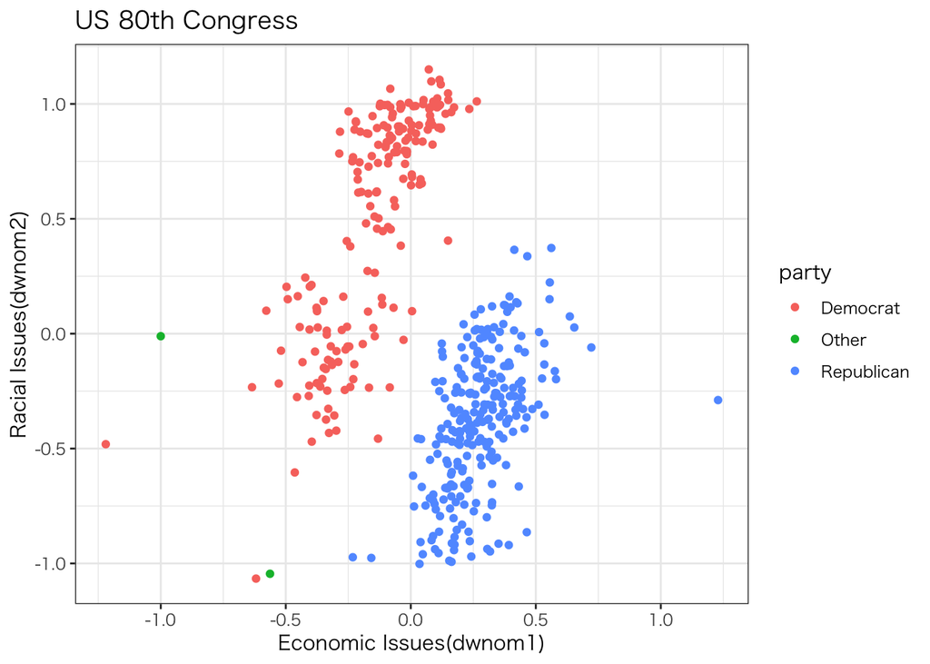

```r
eighty %>%
  ggplot(aes(x = dwnom1, y = dwnom2)) +
  geom_point(aes(color = party)) +
  labs(x = "Economic Issues(dwnom1)",
       y = "Racial Issues(dwnom2)") +
  ggtitle("US 80th Congress") +
  theme_bw(base_family = "HiraKakuProN-W3")
```

- Regarding racial issues (y-axis), Democratic members tend to be more conservative, resulting in a concentration towards the upper side (+) of the graph.
- Regarding economic issues (x-axis), Republican members tend to be more conservative, resulting in a concentration towards the right side (+) of the graph.

## 6.3 Scatterplot of Data for the 112th Congress

- Scatterplot of Data for the 112th Congress

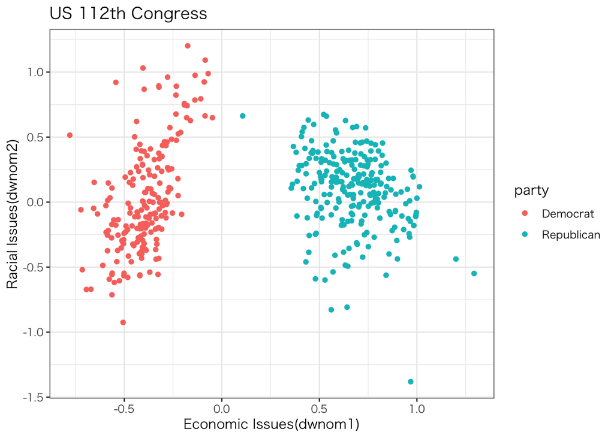

```r
twelve %>%
  ggplot(aes(x = dwnom1, y = dwnom2)) +
  geom_point(aes(color = party)) +
  labs(x = "Economic Issues(dwnom1)",
       y = "Racial Issues(dwnom2)") +
  ggtitle("US 112th Congress") +
  theme_bw(base_family = "HiraKakuProN-W3")
```

- Regarding racial issues (y-axis), both Democratic and Republican members are concentrated around 0.
- The difference between Democratic and Republican members regarding racial issues (y-axis) has disappeared.  
  → The difference in views on racial issues no longer serves as a significant factor in distinguishing between Democrats and Republicans.
- Regarding economic issues (x-axis), Republican members are more conservative, resulting in a concentration on the right side (+) of the graph.  
  → The difference in views on economic issues has become more important in distinguishing between Democrats and Republicans.

# 7. Exercise

#### Q7.1:

- Refer to `1.3 Customizing the Shape of Dots` and draw a scatter plot of ‘election expenses’ and ‘vote percentage’ in the 2009 House of Representatives election.
- Use `shape = 23` to display a `◇` with ‘yellow’ inside and ‘magenta’ outline.

#### Q7.2:

- Refer to `2.2 Adding Dimension by Changing Dot Colors` and draw a scatter plot of ‘election expenses’ and ‘vote percentage’ in the 2009 House of Representatives election.
- Distinguish between candidates from the Liberal Democratic Party and others by using different colors.

#### Q7.3:

- Refer to `2.3 Specifying Dot Colors` and draw a scatter plot of ‘election expenses’ and ‘vote percentage’ in the 2009 House of Representatives election.
- Color the Liberal Democratic Party candidates in ‘red’ and all other candidates in ‘grey’.

#### Q7.4:

- Q1: Refer to `3. Scatter Plot with Regression Line (1)` and draw a scatter plot of ‘election expenses’ and ‘vote percentage’ in the 2005 House of Representatives election.
- Use the `facet_wrap()` function to display scatter plots for each political party, ensuring that the Liberal Democratic Party and the Democratic Party are displayed next to each other.
- Q2: Use the group_by() function to calculate the vote percentage by political party and display the results using the DT::datatable() function.

#### Q7.5:

- Q1: Refer to `4.5 Highlighting Specific Countries` using `{gapminder}` to display a scatter plot of ‘log value of GDP per capita (USD)’ and ‘life expectancy’.
- Choose three countries of interest and display them in different colors.
- Q2: Summarize concisely what can be understood from the above graph.

#### Q7.6:

- Q1: Refer to `5.2 Adding dimensions to a scatter plot` and draw a scatter plot for the 24th (2016) House of Councillors election, with ‘population density of prefectures (did)’ on the x-axis and ‘voting rate of 19-year-old voters (age19)’ on the y-axis.
- Apply logarithmic transformation to variables as needed.  
  = Q2: Summarize concisely what can be understood from the above graph.

**Reference**

[Tidy Animated Verbs](https://github.com/gadenbuie/tidyexplain?fbclid=IwAR3Zt0pQZa0IEvP-1gstatQ42VM5yJZvw2vUaFEqt_m2smUgtZpTqvuurLJ6z0)

[宋財泫 (Jaehyun Song)・矢内勇生 (statuki statanai)「私たちのR: ベストプラクティスの探究」](https://www.jaysong.net/RBook/)

[宋財泫「ミクロ政治データ分析実習（2022年度）」](https://www.jaysong.net/micro-book/)

[土井翔平（北海道大学公共政策大学院）「Rで計量政治学入門」](https://shohei-doi.github.io/quant_polisci/data-import.html)

[矢内勇生（高知工科大学）授業一覧](http://yukiyanai.github.io/teaching/)

浅野正彦, 矢内勇生.『Rによる計量政治学』オーム社、2018年

浅野正彦, 中村公亮.『初めてのRStudio』オーム社、2018年

Kieran Healy, DATA VISUALIZATION, Princeton, 2019

Kosuke Imai, Quantitative Social Science: An Introduction, Princeton University Press, 2017